# final_project

We begin by calculating the daily log returns of the S&P 500 index. To capture the average behavior and volatility of returns over time, we segment the return series into non-overlapping 5-day windows. For each window, we compute the mean (μ) and standard deviation (σ) of log returns, which respectively represent short-term return trends and volatility. These rolling statistics serve as simplified but informative features for identifying underlying market regimes in the following clustering step.

```python
# Define a function to compute rolling statistics (mean μ and standard deviation σ)
# from the log returns of the closing price time series.
def rolling_mu_sigma_from_price(close_series, window=5):
    close_array = close_series.values
    log_returns = np.log(close_array[1:] / close_array[:-1]) # Compute daily log returns

    mu_list, sigma_list, start_dates = [], [], []

    # Iterate through the log returns in non-overlapping windows
    for start in range(0, len(log_returns) - window + 1, window):
        window_returns = log_returns[start:start + window]
        mu = np.mean(window_returns) # Mean of returns (rolling μ)
        sigma = np.std(window_returns) # Standard deviation (rolling σ)
        mu_list.append(mu)
        sigma_list.append(sigma)
        start_dates.append(close_series.index[start + 1])  # Align with date (adjust for shift)

    # Create a DataFrame containing the rolling μ and σ values along with the start date
    df_simple = pd.DataFrame({
        "start_date": start_dates,
        "mu": mu_list,
        "sigma": sigma_list
    })

    return df_simple
```

```python
# Generate the rolling μ and σ features from S&P 500 closing prices using 5-day (one week) non-overlapping windows
df_simple = rolling_mu_sigma_from_price(sp500["Close"], window=5)
df_simple.head()
```

|  | start_date | mu | sigma |
| --- | --- | --- | --- |
| 0 | 2005-05-24 | -0.000396 | 0.004231 |
| 1 | 2005-06-01 | 0.000965 | 0.005052 |
| 2 | 2005-06-08 | 0.001108 | 0.002936 |
| 3 | 2005-06-15 | 0.001605 | 0.002619 |
| 4 | 2005-06-22 | -0.001994 | 0.006939 |

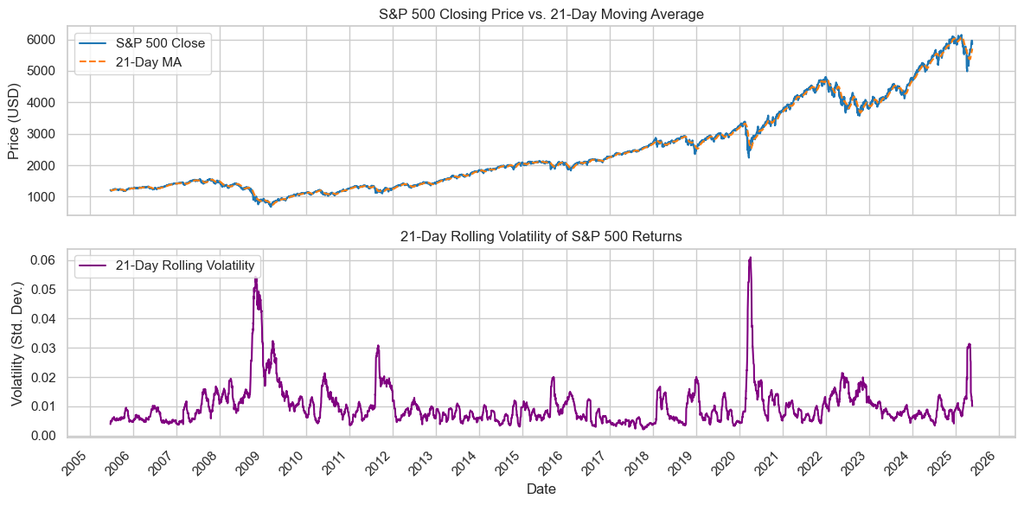

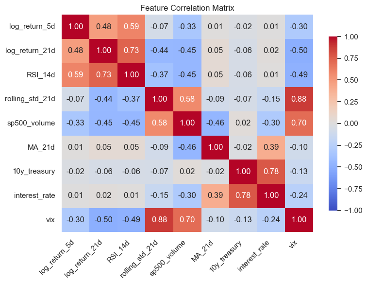

```python
# === 1. Two‐panel time‐series plot: SP500 Close + MA21d and Rolling Volatility ===
fig, axes = plt.subplots(2, 1, figsize=(12, 6), sharex=True)

# Top panel: SP500 close price and 21‐day moving average
axes[0].plot(df.index, df["sp500_close"], label="S&P 500 Close", color="tab:blue")
axes[0].plot(df.index, df["MA_21d"], label="21-Day MA", linestyle="--", color="tab:orange")
axes[0].set_ylabel("Price (USD)")
axes[0].set_title("S&P 500 Closing Price vs. 21-Day Moving Average")
axes[0].legend(loc="upper left")

# Bottom panel: 21-day rolling volatility
axes[1].plot(df.index, df["rolling_std_21d"], label="21-Day Rolling Volatility", color="purple")
axes[1].set_ylabel("Volatility (Std. Dev.)")
axes[1].set_title("21-Day Rolling Volatility of S&P 500 Returns")
axes[1].legend(loc="upper left")


# === 2. Improve x‐axis formatting for “finer” date ticks ===
# Choose a locator—e.g., one tick per year:
year_locator = mdates.YearLocator()       # major tick every January 1st
year_formatter = mdates.DateFormatter('%Y')  # format ticks as “2020”, “2021”, etc.

# (If you wanted quarterly ticks, you could use QuarterLocator(freq=3) and '%Y-%m' for formatting.)
for ax in axes:
    ax.xaxis.set_major_locator(year_locator)
    ax.xaxis.set_major_formatter(year_formatter)
    # Optionally add minor ticks every 6 months:
    ax.xaxis.set_minor_locator(mdates.MonthLocator(bymonth=(1, 7)))
    # Rotate labels on the bottom panel only (since sharex=True, rotating here suffices):
    plt.setp(ax.get_xticklabels(), rotation=45, ha="right")

# Shared x‐axis label
axes[-1].set_xlabel("Date")
plt.tight_layout()
plt.show()


# === 3. Feature Correlation Heatmap ===
# Compute correlation matrix from your standardized feature DataFrame
corr_matrix = X_scaled.corr()

plt.figure(figsize=(8, 6))
sns.heatmap(
    corr_matrix,
    annot=True,
    fmt=".2f",
    cmap="coolwarm",
    vmin=-1,
    vmax=1,
    cbar_kws={"shrink": 0.8}
)
plt.title("Feature Correlation Matrix")
plt.xticks(rotation=45, ha="right")
plt.yticks(rotation=0)
plt.tight_layout()
plt.show()
```

- Use **21-day moving averages** for trend tracking.
- Monitor **volatility spikes** to anticipate risk.
- Combine price and volatility insights for **informed decision-making**.

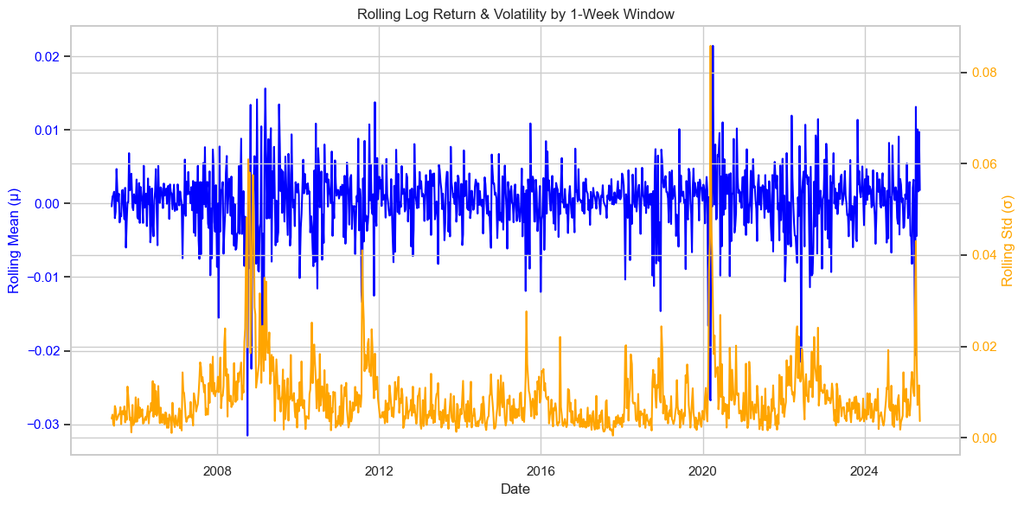

```python
# Plot the evolution of rolling log return (μ) and rolling volatility (σ) over time
# Uses dual y-axes: μ on the left, σ on the right
fig, ax1 = plt.subplots(figsize=(12, 6))
x_dates = df_simple["start_date"]

# Left y-axis: rolling mean return (μ)
ax1.plot(x_dates, df_simple["mu"], color="blue", label="Rolling Mean (μ)")
ax1.set_ylabel("Rolling Mean (μ)", color="blue")
ax1.tick_params(axis='y', labelcolor="blue")

# Right y-axis: rolling standard deviation (σ)
ax2 = ax1.twinx()
ax2.plot(x_dates, df_simple["sigma"], color="orange", label="Rolling Std (σ)")
ax2.set_ylabel("Rolling Std (σ)", color="orange")
ax2.tick_params(axis='y', labelcolor="orange")

# Title and grid
ax1.set_title("Rolling Log Return & Volatility by 1-Week Window")
ax1.set_xlabel("Date")
ax1.grid(True)

plt.tight_layout()
plt.show()
```

This plot shows how the market’s return (μ) and volatility (σ) evolved over time using a 1-week rolling window. Sharp drops in μ often coincide with spikes in σ, highlighting periods of high uncertainty such as the 2008 financial crisis or the 2020 COVID shock.Visualizing these together reveals how periods of stability and turbulence alternate over the dataset.

**Step 2. Cluster market regimes using rolling μ and σ**

```python
# # Winsorization

# from scipy.stats.mstats import winsorize

# # Winsorization parameters
# lower_limit = 0.05   # bottom 5%
# upper_limit = 0.05   # top 5%

# df_simple_winsor = df_simple.copy()

# # Apply Winsorization to 'mu' and 'sigma'
# for col in ["mu", "sigma"]:
#     df_simple_winsor[col] = winsorize(df_simple[col], limits=(lower_limit, upper_limit))

# for col in ["mu", "sigma"]:
#     original_min, original_max = df_simple[col].min(), df_simple[col].max()
#     winsor_min, winsor_max = df_simple_winsor[col].min(), df_simple_winsor[col].max()
#     print(f"{col}:\n  Original range: {original_min:.4f} to {original_max:.4f}")
#     print(f"  Winsorized range: {winsor_min:.4f} to {winsor_max:.4f}\n")
```

In this project, we use rolling mean (`mu`) and standard deviation (`sigma`) of financial returns as inputs for KMeans clustering to identify market regimes. While Winsorization is a common technique for mitigating the influence of extreme outliers, we chose not to apply it. This decision is based on the fact that we are working with only two features, which are derived from rolling windows and tend to be statistically stable and smooth. Visual inspection showed no severe outliers, and both `mu` and `sigma` are robust against short-term fluctuations. Moreover, in financial time series, extreme values often represent meaningful market events—such as crashes or rallies—that are important to capture rather than suppress. Applying Winsorization could mask these signals and reduce the effectiveness of our clustering. However, if we were working in a higher-dimensional feature space—for example, including skewness, kurtosis, or momentum indicators—Winsorization would be more relevant, as outliers in one dimension can disproportionately affect clustering results. In summary, with our clean and interpretable low-dimensional data, Winsorization is unnecessary and could even be counterproductive, though it remains useful in more complex modeling contexts.

```python
#  Extract rolling mean (μ) and standard deviation (σ) values for clustering
X_mu_sigma = df_simple[["mu", "sigma"]].values
# Standardize features to ensure both μ and σ have equal weight in clustering
X_mu_sigma_scaled = StandardScaler().fit_transform(X_mu_sigma)

# Use KMeans to cluster the (μ, σ) pairs
# Try different numbers of clusters (k) from 7 to 20 to find the optimal k
Ks = range(5, 21)
inertias = [] # Inertia (within-cluster sum of squares) for elbow method
sil_scores = [] # Silhouette score to evaluate cluster separation

# Fit KMeans for each k and record performance metrics
for k in Ks:
    km = KMeans(n_clusters=k, n_init=10, random_state=42).fit(X_mu_sigma_scaled)
    inertias.append(km.inertia_)
    sil_scores.append(silhouette_score(X_mu_sigma_scaled, km.labels_))

# Identify the optimal number of clusters (k)
best_idx = np.argmax(sil_scores)
k_best = Ks[best_idx]
print(f"Best k by silhouette score: {k_best}")
```

```
Best k by silhouette score: 5
```

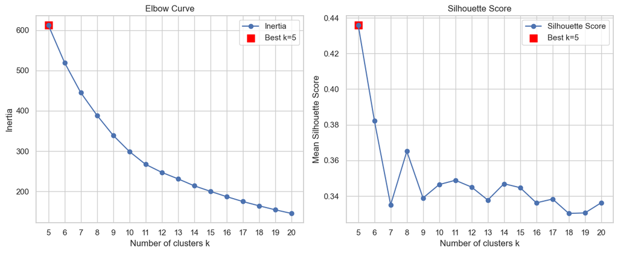

```python
fig, axes = plt.subplots(1, 2, figsize=(12, 5))

# Plot the Elbow Curve to visualize how inertia (within-cluster variance) changes with different k values
# The 'elbow' point indicates diminishing returns and helps identify an appropriate number of clusters
# Elbow Curve (subplot 1)
axes[0].plot(Ks, inertias, marker='o', label='Inertia')
axes[0].scatter([k_best], [inertias[best_idx]], s=100, marker='s', color='red', label=f'Best k={k_best}')
axes[0].set_title('Elbow Curve')
axes[0].set_xlabel('Number of clusters k')
axes[0].set_ylabel('Inertia')
axes[0].set_xticks(Ks)
axes[0].legend()

# Plot the Silhouette Score curve to evaluate how well-separated the clusters are for each k
# Higher silhouette scores indicate better-defined and more cohesive clusters
# The red marker highlights the k value with the highest silhouette score
# Silhouette Score vs. k (subplot 2)
axes[1].plot(Ks, sil_scores, marker='o', label='Silhouette Score')
axes[1].scatter([k_best], [sil_scores[best_idx]], s=100, marker='s', color='red', label=f'Best k={k_best}')
axes[1].set_title('Silhouette Score')
axes[1].set_xlabel('Number of clusters k')
axes[1].set_ylabel('Mean Silhouette Score')
axes[1].set_xticks(Ks)
axes[1].legend()

plt.tight_layout()
plt.show()
```

```python
# Perform final KMeans clustering using the optimal number of clusters (k_best)
# This produces the final regime labels for each 5-day window
final_kmeans = KMeans(n_clusters=k_best, n_init=10, random_state=42)

# Assign the final regime labels to the dataframe
df_simple["regime_best"] = final_kmeans.fit_predict(X_mu_sigma_scaled)
# Display final dataset with regime assignments and descriptive labels
df_simple
```

|  | start_date | mu | sigma | regime_best |
| --- | --- | --- | --- | --- |
| 0 | 2005-05-24 | -0.000396 | 0.004231 | 0 |
| 1 | 2005-06-01 | 0.000965 | 0.005052 | 0 |
| 2 | 2005-06-08 | 0.001108 | 0.002936 | 0 |
| 3 | 2005-06-15 | 0.001605 | 0.002619 | 0 |
| 4 | 2005-06-22 | -0.001994 | 0.006939 | 0 |
| ... | ... | ... | ... | ... |
| 1001 | 2025-04-15 | -0.004422 | 0.017915 | 1 |
| 1002 | 2025-04-23 | 0.010071 | 0.007156 | 3 |
| 1003 | 2025-04-30 | 0.001650 | 0.008275 | 0 |
| 1004 | 2025-05-07 | 0.009734 | 0.011469 | 3 |
| 1005 | 2025-05-14 | 0.001823 | 0.003634 | 0 |

1006 rows × 4 columns

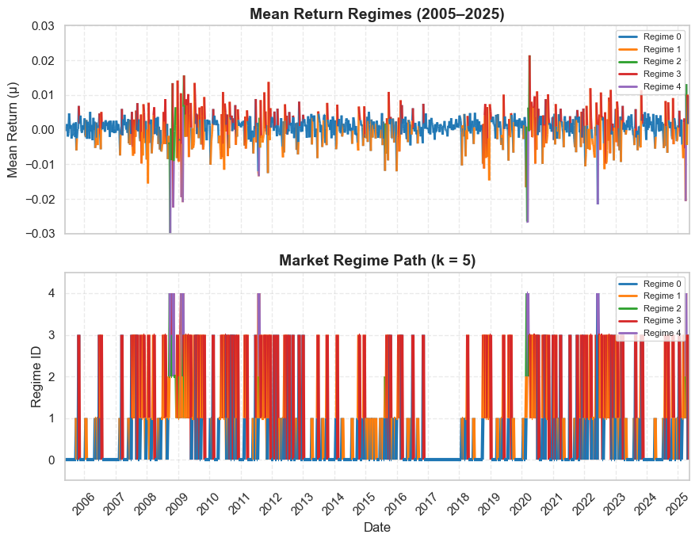

```python
# Convert dates to numeric format
x_num = date2num(df_simple["start_date"])
y_values = df_simple["mu"].to_numpy()
regimes = df_simple["regime_best"].to_numpy()

# Prepare colors for the mean return plot segments
cmap = plt.get_cmap("tab10")
regime_colors_mean = [cmap(r % 10) for r in regimes[:-1]]

# Build line segments for the mean return plot
points_mean = np.array(list(zip(x_num, y_values))).reshape(-1, 1, 2)
segments_mean = np.concatenate([points_mean[:-1], points_mean[1:]], axis=1)
lc_mean = LineCollection(segments_mean, colors=regime_colors_mean, linewidths=2, alpha=0.9)

# Prepare the regime path plot data
y_regime = regimes
regime_colors_path = [cmap(r % 10) for r in y_regime[:-1]]
points_path = np.array(list(zip(x_num, y_regime))).reshape(-1, 1, 2)
segments_path = np.concatenate([points_path[:-1], points_path[1:]], axis=1)
lc_path = LineCollection(segments_path, colors=regime_colors_path, linewidths=3)

# Create a 2x1 subplot
fig, (ax1, ax2) = plt.subplots(2, 1, figsize=(9, 7), sharex=True)

# ---- Subplot 1: Mean Return Regimes ----
ax1.add_collection(lc_mean)
ax1.set_xlim(x_num.min(), x_num.max())
ax1.set_ylim(-0.03, 0.03)  # adjust as needed
ax1.set_title("Mean Return Regimes (2005–2025)", fontsize=14, fontweight='bold')
ax1.set_ylabel("Mean Return (μ)", fontsize=12)
ax1.grid(True, linestyle='--', alpha=0.4)
ax1.xaxis.set_major_locator(YearLocator())
ax1.xaxis.set_minor_locator(MonthLocator(bymonth=[6]))
ax1.xaxis.set_major_formatter(DateFormatter('%Y'))
ax1.tick_params(axis='x', rotation=45)

# Legend for regime colors in mean return plot
unique_regs = np.unique(regimes)
legend_lines = [
    Line2D([0], [0], color=cmap(r % 10), lw=2, label=f"Regime {r}")
    for r in unique_regs
]
ax1.legend(handles=legend_lines, loc='upper right', fontsize=8)

# ---- Subplot 2: Market Regime Path ----
ax2.add_collection(lc_path)
ax2.set_xlim(x_num.min(), x_num.max())
ax2.set_ylim(y_regime.min() - 0.5, y_regime.max() + 0.5)
ax2.set_title(f"Market Regime Path (k = {k_best})", fontsize=14, fontweight='bold')
ax2.set_ylabel("Regime ID", fontsize=12)
ax2.set_xlabel("Date", fontsize=12)
ax2.set_yticks(np.sort(unique_regs))
ax2.grid(True, linestyle='--', alpha=0.4)
ax2.xaxis.set_major_locator(YearLocator())
ax2.xaxis.set_minor_locator(MonthLocator(bymonth=[6]))
ax2.xaxis.set_major_formatter(DateFormatter('%Y'))
ax2.tick_params(axis='x', rotation=45)

# Add the same legend to the second plot
ax2.legend(handles=legend_lines, loc='upper right', fontsize=8)

plt.tight_layout()
plt.show()
```

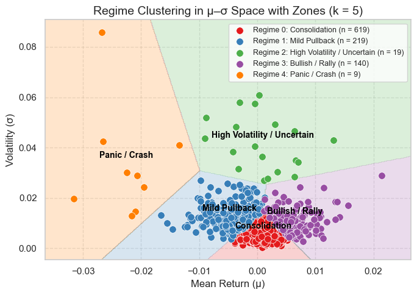

```python
# Regime clustering (detection) plot in μ-σ space

sns.set_theme(style="whitegrid", context="notebook")

X_mu_sigma = df_simple[["mu", "sigma"]].values
scaler = StandardScaler()
X_scaled_new = scaler.fit_transform(X_mu_sigma)

kmeans = KMeans(n_clusters=k_best, n_init=10, random_state=42).fit(X_scaled_new)
df_simple["regime_best"] = kmeans.labels_
centers = scaler.inverse_transform(kmeans.cluster_centers_)

regime_labels_en = [
    "Consolidation",
    "Mild Pullback",
    "High Volatility / Uncertain",
    "Bullish / Rally",
    "Panic / Crash"]
color_list = sns.color_palette("Set1", k_best)
counts = df_simple["regime_best"].value_counts().sort_index()

x_min, x_max = X_mu_sigma[:, 0].min() - 0.005, X_mu_sigma[:, 0].max() + 0.005
y_min, y_max = X_mu_sigma[:, 1].min() - 0.005, X_mu_sigma[:, 1].max() + 0.005
xx, yy = np.meshgrid(np.linspace(x_min, x_max, 500),
                     np.linspace(y_min, y_max, 500))
grid = np.c_[xx.ravel(), yy.ravel()]
grid_scaled = scaler.transform(grid)
Z = kmeans.predict(grid_scaled)
Z = Z.reshape(xx.shape)

plt.figure(figsize=(7,5))
plt.contourf(xx, yy, Z, alpha=0.2, levels=np.arange(k_best+1)-0.5, colors=color_list)
for i in range(k_best):
    cluster_data = df_simple[df_simple["regime_best"] == i]
    plt.scatter(cluster_data["mu"], cluster_data["sigma"],
                color=color_list[i],
                label=f"Regime {i}: {regime_labels_en[i]} (n = {counts[i]})",
                s=70, edgecolor='white', linewidth=0.5)
    x, y = centers[i]
    plt.text(x, y + 0.0025, regime_labels_en[i], fontsize=10, ha='center', weight='bold', color='black')

plt.title(f"Regime Clustering in μ–σ Space with Zones (k = {k_best})", fontsize=14)
plt.xlabel("Mean Return (μ)", fontsize=12)
plt.ylabel("Volatility (σ)", fontsize=12)
plt.grid(True, linestyle='--', alpha=0.5)
plt.legend(loc="best", fontsize=9)
plt.tight_layout()
plt.show()
```

```python
# Summarize the characteristics of each market regime
# Calculate the average return (μ) and volatility (σ) within each cluster

df_regime_stats = df_simple.groupby("regime_best")[["mu", "sigma"]].mean().sort_values("mu", ascending=False)
print(df_regime_stats)
```

```
                   mu     sigma
regime_best
3            0.006513  0.011082
0            0.001037  0.005304
2            0.000916  0.041532
1           -0.004781  0.012457
4           -0.022587  0.033351
```

Based on the table and plot shown above, we can interpret the regimes as follows:

- **Regime 0**: Consolidation: μ = 0.001037, σ = 0.005304, n = 619. This regime reflects stable markets with low volatility and near-zero returns, indicating sideways price movement and investor indecision.
- **Regime 1**: Mild Pullback: μ = -0.004781, σ = 0.012457, n = 219. Slightly negative returns with moderate volatility suggest short-term corrections or minor downward movements within a larger trend.
- **Regime 2**: High Volatility / Uncertain: μ = 0.000916, σ = 0.041532, n = 19. High volatility with neutral returns implies a highly uncertain market environment, often driven by macroeconomic or geopolitical shocks.
- **Regime 3**: Bullish / Rally: μ = 0.006513, σ = 0.011082, n = 140. Positive returns with low volatility characterize a strong upward trend and market optimism.
- **Regime 4**: Panic / Crash: μ = -0.022587, σ = 0.033351, n = 9. Sharp negative returns and high volatility indicate market distress, panic selling, or systemic risk events.

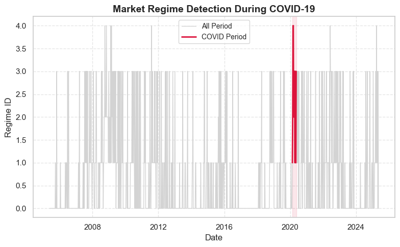

```
Regime Distribution During COVID Period:
Regime 1: Mild Pullback                  — 4 windows
Regime 2: High Volatility / Uncertain    — 3 windows
Regime 3: Bullish / Rally                — 4 windows
Regime 4: Panic / Crash                  — 2 windows
```

```python
# Step: Define COVID window
covid_start = pd.to_datetime("2020-02-15")
covid_end = pd.to_datetime("2020-05-15")
df_covid = df_simple[(df_simple["start_date"] >= covid_start) & (df_simple["start_date"] <= covid_end)]

# Plot regime path with COVID highlighting
plt.figure(figsize=(8, 5))

# Full regime path (light gray)
plt.plot(df_simple["start_date"], df_simple["regime_best"], color='lightgray', label="All Period", linewidth=1)

# COVID regime path (highlighted)
plt.plot(df_covid["start_date"], df_covid["regime_best"], color='crimson', linewidth=2, label="COVID Period")

# Add shaded COVID window
plt.axvspan(covid_start, covid_end, color='crimson', alpha=0.1)
plt.xlabel("Date", fontsize=12)
plt.ylabel("Regime ID", fontsize=12)
plt.title("Market Regime Detection During COVID-19", fontsize=14, weight='bold')
plt.grid(True, linestyle='--', alpha=0.5)
plt.legend(fontsize=10)
plt.tight_layout()
plt.show()

# regime distribution during COVID
print("Regime Distribution During COVID Period:")
covid_counts = df_covid["regime_best"].value_counts().sort_index()
for i, count in covid_counts.items():
    label = regime_labels_en[i]
    print(f"Regime {i}: {label:<30} — {count} windows")
```